# Genome-wide methylation analysis report

- study: ePTB_girls_noNAbetas_twoCells_rlm_adj
- author: DJQ
- date: 19 November, 2025

## Parameters

```
## $sig.threshold
## [1] 5.389319e-08
##
## $max.plots
## [1] 10
##
## $qq.inflation.method
## [1] "median"
##
## $practical.threshold
## [1] 2.130536e-33
```

## Sample characteristics

For continuous or ordinal variables, the “mean” column provides the mean and the “sd/%” column the standard deviation of the variable. For categorical variables, the “mean” column provides the number of samples with the given “value” and the “sd/%” column the percentage of samples with the given “value”.

| variable | value | mean | sd.. |
| --- | --- | --- | --- |
| eptb_binePTB case |  | 0.4104478 | 0.4937609 |
| A2age |  | 28.1194 | 6.644626 |
| gravidityprimiparous |  | 0.3134328 | 0.4656293 |
| employedYes |  | 0.5746269 | 0.4962546 |
| prebmi |  | 25.79289 | 4.847413 |
| Epi |  | 0.9075922 | 0.1187852 |
| B |  | 0.01670788 | 0.01570904 |
| NK |  | 0.01751494 | 0.01518098 |
| CD4T |  | 0.008353549 | 0.007015509 |
| CD8T |  | 0.000117373 | 0.0009814905 |
| Mono |  | 0.01498028 | 0.01729844 |
| Neutro |  | 0.03234451 | 0.07356805 |
| Eosino |  | 0.002278332 | 0.002035479 |
| sv1 |  | 3.181456e-17 | 0.086711 |
| sv2 |  | 2.095281e-18 | 0.086711 |
| sv3 |  | -2.570419e-17 | 0.086711 |
| sv4 |  | 2.181613e-17 | 0.086711 |
| sv5 |  | 1.719371e-17 | 0.086711 |
| sv6 |  | 2.317401e-17 | 0.086711 |
| sv7 |  | 2.648829e-17 | 0.086711 |
| sv8 |  | -5.851455e-18 | 0.086711 |
| sv9 |  | 5.721374e-17 | 0.086711 |
| sv10 |  | -1.551987e-17 | 0.086711 |

## Covariate associations

### Covariate A2age

statistics

| var1 | var2 | F | p-value | R | p-value |
| --- | --- | --- | --- | --- | --- |
| eptb_binePTB case | A2age | 5.653762 | 0.0188522 | 0.2047286 | 0.0176494 |

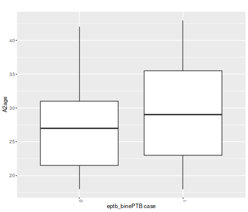

### Covariate gravidityprimiparous

statistics

| var1 | var2 | F | p-value | R | p-value |
| --- | --- | --- | --- | --- | --- |
| eptb_binePTB case | gravidityprimiparous | 2.58625 | 0.1101845 | -0.1386229 | 0.1101845 |

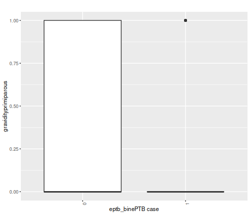

### Covariate employedYes

statistics

| var1 | var2 | F | p-value | R | p-value |
| --- | --- | --- | --- | --- | --- |
| eptb_binePTB case | employedYes | 0.0454295 | 0.831545 | -0.0185484 | 0.831545 |

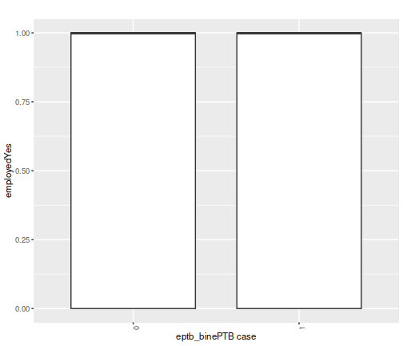

### Covariate prebmi

statistics

| var1 | var2 | F | p-value | R | p-value |
| --- | --- | --- | --- | --- | --- |
| eptb_binePTB case | prebmi | 1.215984 | 0.2721566 | 0.1062869 | 0.2215945 |

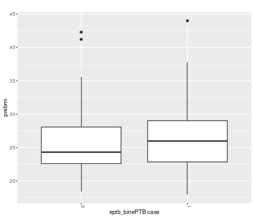

### Covariate Epi

statistics

| var1 | var2 | F | p-value | R | p-value |
| --- | --- | --- | --- | --- | --- |
| eptb_binePTB case | Epi | 0.5958614 | 0.4415412 | -0.0056868 | 0.9480038 |

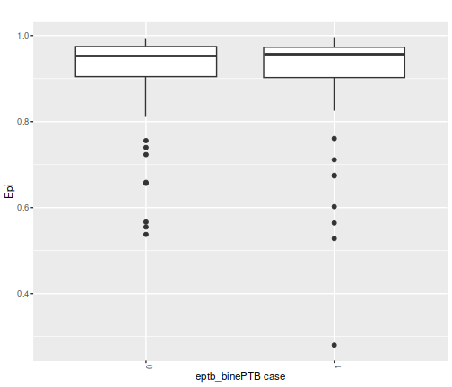

### Covariate B

statistics

| var1 | var2 | F | p-value | R | p-value |
| --- | --- | --- | --- | --- | --- |
| eptb_binePTB case | B | 0.370967 | 0.5435245 | 0.0272576 | 0.7545605 |

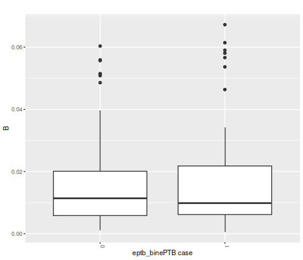

### Covariate NK

statistics

| var1 | var2 | F | p-value | R | p-value |
| --- | --- | --- | --- | --- | --- |
| eptb_binePTB case | NK | 0.00678 | 0.9345007 | -0.0103932 | 0.905128 |

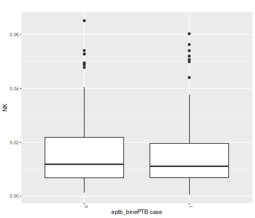

### Covariate CD4T

statistics

| var1 | var2 | F | p-value | R | p-value |
| --- | --- | --- | --- | --- | --- |
| eptb_binePTB case | CD4T | 0.0222821 | 0.8815668 | -0.0147073 | 0.866061 |

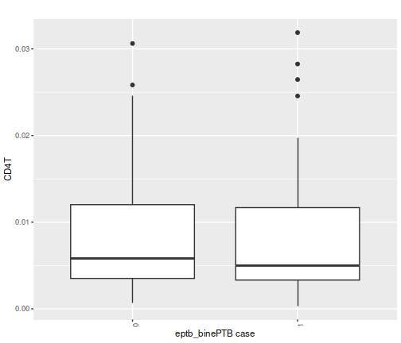

### Covariate CD8T

statistics

| var1 | var2 | F | p-value | R | p-value |
| --- | --- | --- | --- | --- | --- |
| eptb_binePTB case | CD8T | 2.403056 | 0.1234927 | 0.0345895 | 0.691537 |

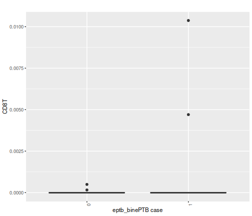

### Covariate Mono

statistics

| var1 | var2 | F | p-value | R | p-value |
| --- | --- | --- | --- | --- | --- |
| eptb_binePTB case | Mono | 0.4323957 | 0.5119608 | -0.0029415 | 0.9730916 |

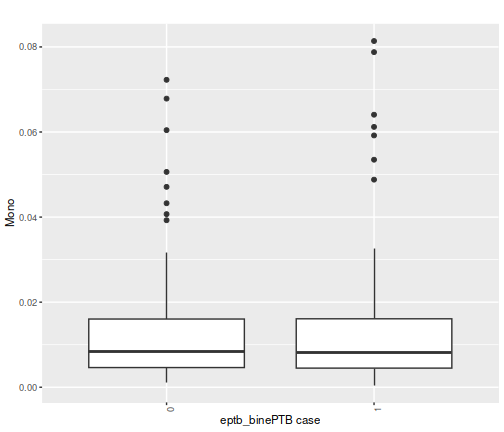

### Covariate Neutro

statistics

| var1 | var2 | F | p-value | R | p-value |
| --- | --- | --- | --- | --- | --- |
| eptb_binePTB case | Neutro | 0.9516672 | 0.3310797 | 0.0354937 | 0.6838988 |

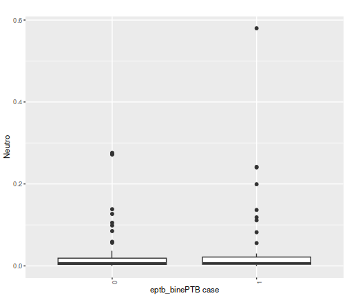

### Covariate Eosino

statistics

| var1 | var2 | F | p-value | R | p-value |
| --- | --- | --- | --- | --- | --- |
| eptb_binePTB case | Eosino | 10.23241 | 0.001728 | -0.3024949 | 0.0003817 |

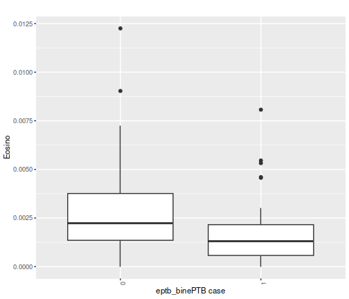

### Covariate sv1

statistics

| var1 | var2 | F | p-value | R | p-value |
| --- | --- | --- | --- | --- | --- |
| eptb_binePTB case | sv1 | 0.74237 | 0.3904652 | 0.0041181 | 0.9623351 |

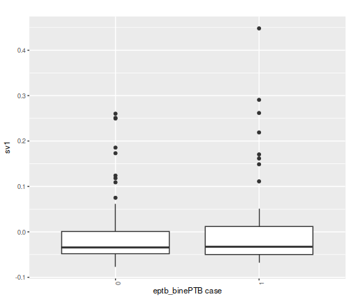

### Covariate sv2

statistics

| var1 | var2 | F | p-value | R | p-value |
| --- | --- | --- | --- | --- | --- |
| eptb_binePTB case | sv2 | 0.213605 | 0.6447172 | -0.0935387 | 0.2823731 |

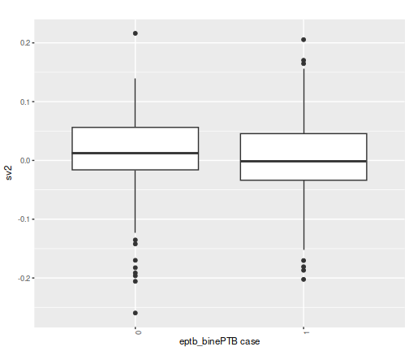

### Covariate sv3

statistics

| var1 | var2 | F | p-value | R | p-value |
| --- | --- | --- | --- | --- | --- |
| eptb_binePTB case | sv3 | 37.19277 | 0 | 0.470439 | 0 |

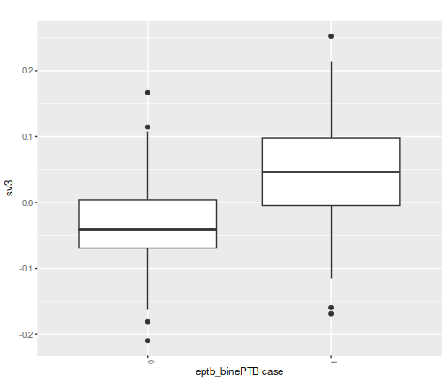

### Covariate sv4

statistics

| var1 | var2 | F | p-value | R | p-value |
| --- | --- | --- | --- | --- | --- |
| eptb_binePTB case | sv4 | 0.611041 | 0.435796 | 0.0656928 | 0.4507652 |

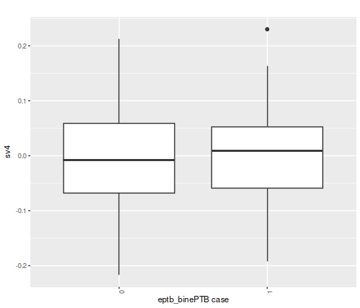

### Covariate sv5

statistics

| var1 | var2 | F | p-value | R | p-value |
| --- | --- | --- | --- | --- | --- |
| eptb_binePTB case | sv5 | 0.7190019 | 0.3980064 | -0.242181 | 0.0048132 |

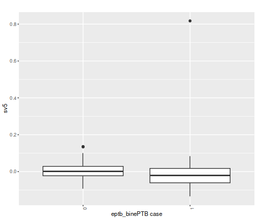

### Covariate sv6

statistics

| var1 | var2 | F | p-value | R | p-value |
| --- | --- | --- | --- | --- | --- |
| eptb_binePTB case | sv6 | 3.801402 | 0.0533297 | 0.1911955 | 0.0268997 |

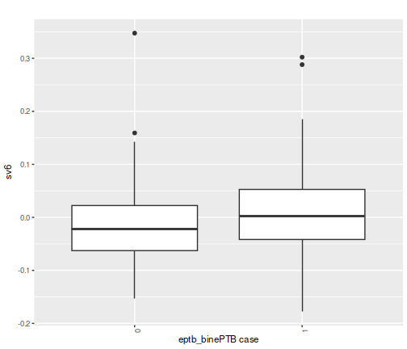

### Covariate sv7

statistics

| var1 | var2 | F | p-value | R | p-value |
| --- | --- | --- | --- | --- | --- |
| eptb_binePTB case | sv7 | 2.440791 | 0.1206109 | 0.0962841 | 0.2684235 |

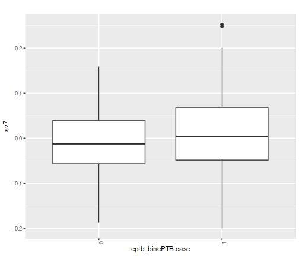

### Covariate sv8

statistics

| var1 | var2 | F | p-value | R | p-value |
| --- | --- | --- | --- | --- | --- |
| eptb_binePTB case | sv8 | 4.388351 | 0.0380965 | 0.1719779 | 0.0469261 |

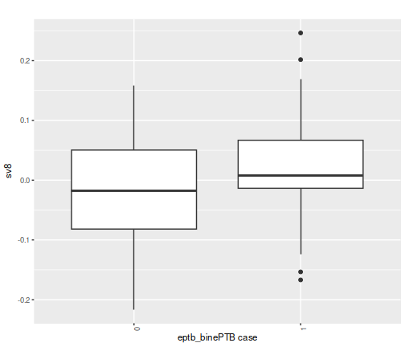

### Covariate sv9

statistics

| var1 | var2 | F | p-value | R | p-value |
| --- | --- | --- | --- | --- | --- |
| eptb_binePTB case | sv9 | 2.366444 | 0.1263628 | -0.1335427 | 0.1239791 |

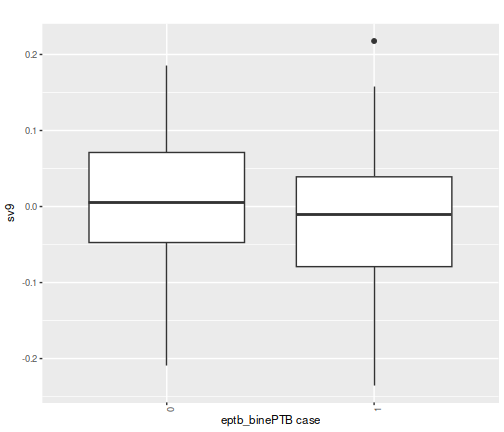

### Covariate sv10

statistics

| var1 | var2 | F | p-value | R | p-value |
| --- | --- | --- | --- | --- | --- |
| eptb_binePTB case | sv10 | 0.866939 | 0.3535039 | -0.0543191 | 0.5330487 |

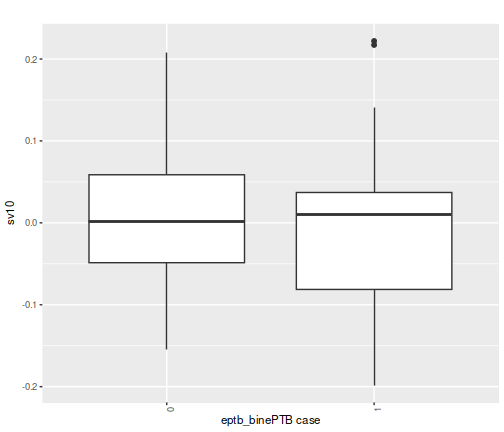

## QQ plots

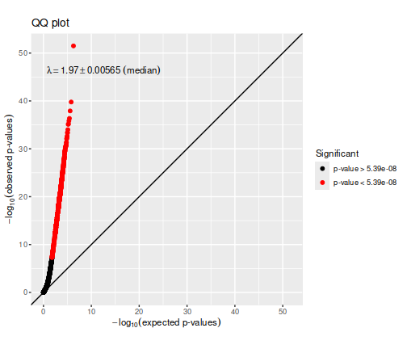

## Manhattan plots

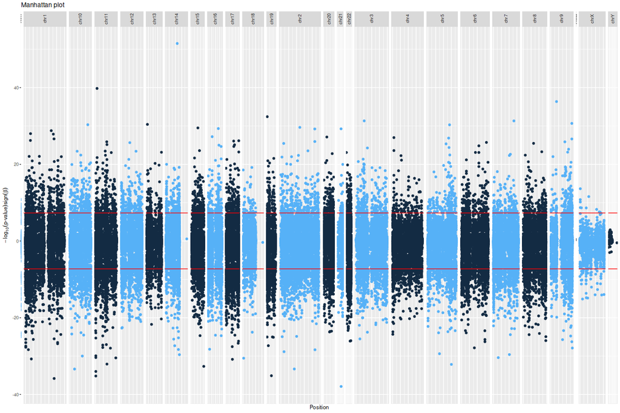

## Significant CpG sites

There were 15375 CpG sites with association p-values < 5.389319 × 10<sup>-8</sup>. These are listed in the file associations.csv.

Below are the 10 CpG sites with association p-values < 2.1305357 × 10<sup>-33</sup> in the regression model.

|  | chromosome | position | estimate | p.value | p.adjust |
| --- | --- | --- | --- | --- | --- |
| cg00221747 | chr11 | 2131198 | -0.1417587 | 0 | 0 |
| cg10389138 | chr2 | 85770945 | -0.0684811 | 0 | 0 |
| cg01668279 | chr11 | 2135469 | -0.1151647 | 0 | 0 |
| cg08849509 | chr11 | 9815661 | 0.1335428 | 0 | 0 |
| cg17966268 | chr10 | 29760694 | -0.1259061 | 0 | 0 |
| cg17759716 | chr21 | 33858623 | -0.0498835 | 0 | 0 |
| cg16943230 | chr14 | 91466411 | 0.2040635 | 0 | 0 |
| cg16109426 | chr9 | 36566818 | 0.1037913 | 0 | 0 |
| cg24366687 | chr19 | 29817228 | -0.0843948 | 0 | 0 |
| cg01699305 | chr1 | 183882582 | -0.1746513 | 0 | 0 |

Plots of these sites follow, one for each covariate set. “p[lm]” denotes the p-value obtained using a linear model and “p[beta]” the p-value obtained using beta regression.

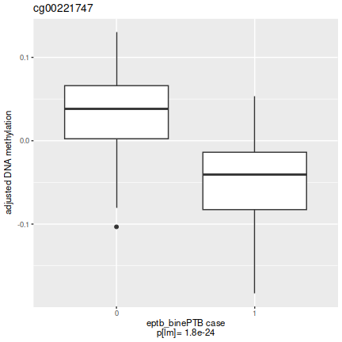

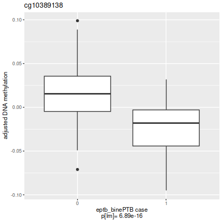

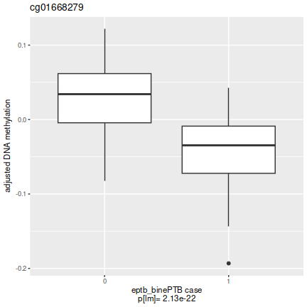

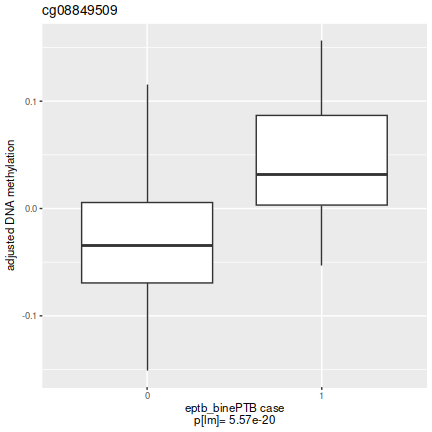

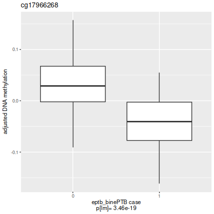

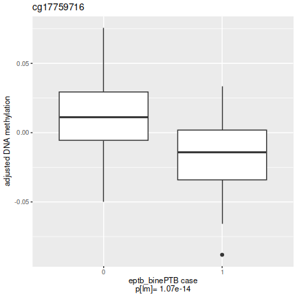

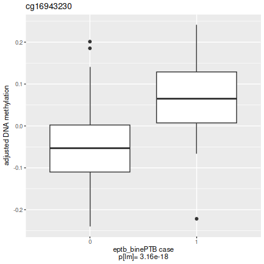

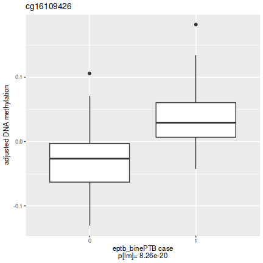

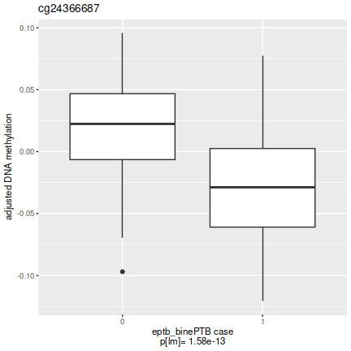

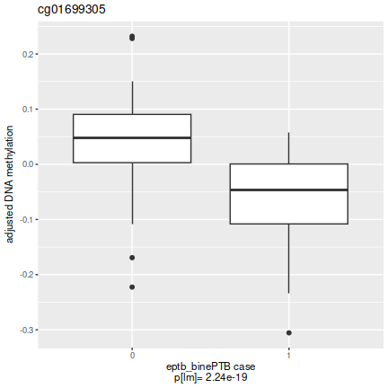

## Selected CpG sites

Number of CpG sites selected: 0.

| chromosome | position | estimate | p.value | p.adjust |
| --- | --- | --- | --- | --- |